# (Somewhat) advanced NLP: text vectorization

Daniel S. Hain (dsh@business.aau.dk)

Updated November 03, 2020

```r
### Load standardpackages
library(tidyverse) # Collection of all the good stuff like dplyr, ggplot2 ect.
library(magrittr) # For extra-piping operators (eg. %<>%)
```

```r
library(tidytext)
```

# Refresher:

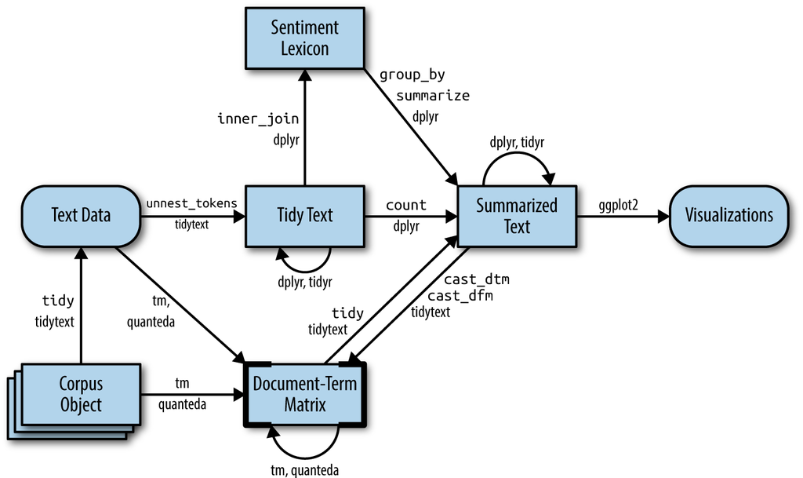

# Bag of words model

- In order for a computer to understand text we need to somehow find a useful representation.
- If you need to compare different texts e.g. articles, you will probably go for keywords. These keywords may come from a keyword-list with for example 200 different keywords
- In that case you could represent each document with a (sparse) vector with 1 for “keyword present” and 0 for “keyword absent”
- We can also get a bit more sophoistocated and count the number of times a word from our dictionary occurs.
- For a corpus of documents that would give us a document-term matrix.

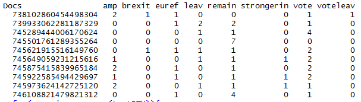

example

Let’s try creating a bag of words model from our initial example.

```r
text <- tibble(id = c(1:6),
               text = c('A text about cats.',
                        'A text about dogs.',
                        'And another text about a dog.',
                        'Why always writing about cats and dogs, always dogs?',
                        'There are too little text about cats but to many about dogs',
                        'Cats, cats, cats! I love cats soo much. Cats are way better than dogs'))
```

```r
text_tidy <- text %>%
  unnest_tokens(word, text, token = 'words') %>%
  count(id, word)
```

## The document-term matrix (DTM)

- The simplest form of vector representation of text is a ddocument-term matrix
- How to we get a document-term matrix now?
- We could do it by hand, with well-known `dplyr` syntax (Note: only works when you have one row per unique document-word pair)

```r
text_tidy %>%
  pivot_wider(names_from = word, values_from = n, values_fill = 0)
```

| id | a | about | cats | text | dogs | and | another | dog | always | why | writing | are | but | little | many | there | to | too | better | i | love | much | soo | than | way |
| --- | --- | --- | --- | --- | --- | --- | --- | --- | --- | --- | --- | --- | --- | --- | --- | --- | --- | --- | --- | --- | --- | --- | --- | --- | --- |
| 1 | 1 | 1 | 1 | 1 | 0 | 0 | 0 | 0 | 0 | 0 | 0 | 0 | 0 | 0 | 0 | 0 | 0 | 0 | 0 | 0 | 0 | 0 | 0 | 0 | 0 |
| 2 | 1 | 1 | 0 | 1 | 1 | 0 | 0 | 0 | 0 | 0 | 0 | 0 | 0 | 0 | 0 | 0 | 0 | 0 | 0 | 0 | 0 | 0 | 0 | 0 | 0 |
| 3 | 1 | 1 | 0 | 1 | 0 | 1 | 1 | 1 | 0 | 0 | 0 | 0 | 0 | 0 | 0 | 0 | 0 | 0 | 0 | 0 | 0 | 0 | 0 | 0 | 0 |
| 4 | 0 | 1 | 1 | 0 | 2 | 1 | 0 | 0 | 2 | 1 | 1 | 0 | 0 | 0 | 0 | 0 | 0 | 0 | 0 | 0 | 0 | 0 | 0 | 0 | 0 |
| 5 | 0 | 2 | 1 | 1 | 1 | 0 | 0 | 0 | 0 | 0 | 0 | 1 | 1 | 1 | 1 | 1 | 1 | 1 | 0 | 0 | 0 | 0 | 0 | 0 | 0 |
| 6 | 0 | 0 | 5 | 0 | 1 | 0 | 0 | 0 | 0 | 0 | 0 | 1 | 0 | 0 | 0 | 0 | 0 | 0 | 1 | 1 | 1 | 1 | 1 | 1 | 1 |

- We could also use `cast_dtm()` to create a DTM in the format of the `tm` package.

```r
text_dtm <- text_tidy %>%
  cast_dtm(id, word, n)
```

```r
text_dtm
```

```
<<DocumentTermMatrix (documents: 6, terms: 25)>>
Non-/sparse entries: 42/108
Sparsity           : 72%
Maximal term length: 7
Weighting          : term frequency (tf)
```

- We can simply convert ig to a tibble. Since there exists no direct transfer function, we have to first transform it to a matrix.
- Notice how we recover the rownames

```r
text_dtm %>% as.matrix() %>% as_tibble(rownames = 'id')
```

| id | a | about | cats | text | dogs | and | another | dog | always | why | writing | are | but | little | many | there | to | too | better | i | love | much | soo | than | way |
| --- | --- | --- | --- | --- | --- | --- | --- | --- | --- | --- | --- | --- | --- | --- | --- | --- | --- | --- | --- | --- | --- | --- | --- | --- | --- |
| 1 | 1 | 1 | 1 | 1 | 0 | 0 | 0 | 0 | 0 | 0 | 0 | 0 | 0 | 0 | 0 | 0 | 0 | 0 | 0 | 0 | 0 | 0 | 0 | 0 | 0 |
| 2 | 1 | 1 | 0 | 1 | 1 | 0 | 0 | 0 | 0 | 0 | 0 | 0 | 0 | 0 | 0 | 0 | 0 | 0 | 0 | 0 | 0 | 0 | 0 | 0 | 0 |
| 3 | 1 | 1 | 0 | 1 | 0 | 1 | 1 | 1 | 0 | 0 | 0 | 0 | 0 | 0 | 0 | 0 | 0 | 0 | 0 | 0 | 0 | 0 | 0 | 0 | 0 |
| 4 | 0 | 1 | 1 | 0 | 2 | 1 | 0 | 0 | 2 | 1 | 1 | 0 | 0 | 0 | 0 | 0 | 0 | 0 | 0 | 0 | 0 | 0 | 0 | 0 | 0 |
| 5 | 0 | 2 | 1 | 1 | 1 | 0 | 0 | 0 | 0 | 0 | 0 | 1 | 1 | 1 | 1 | 1 | 1 | 1 | 0 | 0 | 0 | 0 | 0 | 0 | 0 |
| 6 | 0 | 0 | 5 | 0 | 1 | 0 | 0 | 0 | 0 | 0 | 0 | 1 | 0 | 0 | 0 | 0 | 0 | 0 | 1 | 1 | 1 | 1 | 1 | 1 | 1 |

- Sidenote: We can also tidy the DTM again to a tidy token-dataframe.

```r
text_dtm %>% tidy()
```

| document | term | count |
| --- | --- | --- |
| 1 | a | 1 |
| 2 | a | 1 |
| 3 | a | 1 |
| 1 | about | 1 |
| 2 | about | 1 |
| 3 | about | 1 |
| 4 | about | 1 |
| 5 | about | 2 |
| 1 | cats | 1 |
| 4 | cats | 1 |

[output cut: 32 more lines]

- We also can directly use a similar function to cast a sparse matrix (which we for sure then also could transform to a tibble again)

```r
text_tidy %>% cast_sparse(row = id, column = word, value = n)
```

```
6 x 25 sparse Matrix of class "dgCMatrix"

1 1 1 1 1 . . . . . . . . . . . . . . . . . . . . .
2 1 1 . 1 1 . . . . . . . . . . . . . . . . . . . .
3 1 1 . 1 . 1 1 1 . . . . . . . . . . . . . . . . .
4 . 1 1 . 2 1 . . 2 1 1 . . . . . . . . . . . . . .
5 . 2 1 1 1 . . . . . . 1 1 1 1 1 1 1 . . . . . . .
6 . . 5 . 1 . . . . . . 1 . . . . . . 1 1 1 1 1 1 1
```

- Finally, we could just apply a text recipe here

```r
library(recipes)
library(textrecipes)
```

```r
text %>%
  recipe(~.) %>%
  step_tokenize(text, token = 'words') %>% # tokenize
  step_tf(text) %>% # TFIDF weighting
  prep() %>% juice()
```

| id | tf_text_a | tf_text_about | tf_text_always | tf_text_and | tf_text_another | tf_text_are | tf_text_better | tf_text_but | tf_text_cats | tf_text_dog | tf_text_dogs | tf_text_i | tf_text_little | tf_text_love | tf_text_many | tf_text_much | tf_text_soo | tf_text_text | tf_text_than | tf_text_there | tf_text_to | tf_text_too | tf_text_way | tf_text_why | tf_text_writing |
| --- | --- | --- | --- | --- | --- | --- | --- | --- | --- | --- | --- | --- | --- | --- | --- | --- | --- | --- | --- | --- | --- | --- | --- | --- | --- |
| 1 | 1 | 1 | 0 | 0 | 0 | 0 | 0 | 0 | 1 | 0 | 0 | 0 | 0 | 0 | 0 | 0 | 0 | 1 | 0 | 0 | 0 | 0 | 0 | 0 | 0 |
| 2 | 1 | 1 | 0 | 0 | 0 | 0 | 0 | 0 | 0 | 0 | 1 | 0 | 0 | 0 | 0 | 0 | 0 | 1 | 0 | 0 | 0 | 0 | 0 | 0 | 0 |
| 3 | 1 | 1 | 0 | 1 | 1 | 0 | 0 | 0 | 0 | 1 | 0 | 0 | 0 | 0 | 0 | 0 | 0 | 1 | 0 | 0 | 0 | 0 | 0 | 0 | 0 |
| 4 | 0 | 1 | 2 | 1 | 0 | 0 | 0 | 0 | 1 | 0 | 2 | 0 | 0 | 0 | 0 | 0 | 0 | 0 | 0 | 0 | 0 | 0 | 0 | 1 | 1 |
| 5 | 0 | 2 | 0 | 0 | 0 | 1 | 0 | 1 | 1 | 0 | 1 | 0 | 1 | 0 | 1 | 0 | 0 | 1 | 0 | 1 | 1 | 1 | 0 | 0 | 0 |
| 6 | 0 | 0 | 0 | 0 | 0 | 1 | 1 | 0 | 5 | 0 | 1 | 1 | 0 | 1 | 0 | 1 | 1 | 0 | 1 | 0 | 0 | 0 | 1 | 0 | 0 |

## TF-IDF - Term Frequency - Inverse Document Frequency

- A token is important for a document if appears very often
- A token becomes less important for comparison across a corpus if it appears all over the place in the corpus
- *Cat* in a corpus of websites talking about cats is not that important

$$w_{i,j} = tf_{i,j}*log(\frac{N}{df_i})$$

- $w_{i,j}$ = the TF-IDF score for a term i in a document j
- $tf_{i,j}$ = number of occurence of term i in document j
- $N$ = number of documents in the corpus
- $df_i$ = number of documents with term i

```r
# TFIDF weights
text_tidy %<>%
  bind_tf_idf(term = word,
              document = id,
              n = n)
```

- We obviously could also cast a tf_idf weighted dtm…

```r
text_tidy %>%
  select(id, word, tf_idf) %>%
  pivot_wider(names_from = word, values_from = tf_idf, values_fill = 0)
```

| id | a | about | cats | text | dogs | and | another | dog | always | why | writing | are | but | little | many | there | to | too | better | i | love | much | soo | than | way |
| --- | --- | --- | --- | --- | --- | --- | --- | --- | --- | --- | --- | --- | --- | --- | --- | --- | --- | --- | --- | --- | --- | --- | --- | --- | --- |
| 1 | 0.1732868 | 0.04558039 | 0.10136628 | 0.10136628 | 0.00000000 | 0.000000 | 0.0000000 | 0.0000000 | 0.0000000 | 0.0000000 | 0.0000000 | 0.00000000 | 0.0000000 | 0.0000000 | 0.0000000 | 0.0000000 | 0.0000000 | 0.0000000 | 0.0000000 | 0.0000000 | 0.0000000 | 0.0000000 | 0.0000000 | 0.0000000 | 0.0000000 |
| 2 | 0.1732868 | 0.04558039 | 0.00000000 | 0.10136628 | 0.10136628 | 0.000000 | 0.0000000 | 0.0000000 | 0.0000000 | 0.0000000 | 0.0000000 | 0.00000000 | 0.0000000 | 0.0000000 | 0.0000000 | 0.0000000 | 0.0000000 | 0.0000000 | 0.0000000 | 0.0000000 | 0.0000000 | 0.0000000 | 0.0000000 | 0.0000000 | 0.0000000 |
| 3 | 0.1155245 | 0.03038693 | 0.00000000 | 0.06757752 | 0.00000000 | 0.183102 | 0.2986266 | 0.2986266 | 0.0000000 | 0.0000000 | 0.0000000 | 0.00000000 | 0.0000000 | 0.0000000 | 0.0000000 | 0.0000000 | 0.0000000 | 0.0000000 | 0.0000000 | 0.0000000 | 0.0000000 | 0.0000000 | 0.0000000 | 0.0000000 | 0.0000000 |
| 4 | 0.0000000 | 0.02025795 | 0.04505168 | 0.00000000 | 0.09010336 | 0.122068 | 0.0000000 | 0.0000000 | 0.3981688 | 0.1990844 | 0.1990844 | 0.00000000 | 0.0000000 | 0.0000000 | 0.0000000 | 0.0000000 | 0.0000000 | 0.0000000 | 0.0000000 | 0.0000000 | 0.0000000 | 0.0000000 | 0.0000000 | 0.0000000 | 0.0000000 |
| 5 | 0.0000000 | 0.03038693 | 0.03378876 | 0.03378876 | 0.03378876 | 0.000000 | 0.0000000 | 0.0000000 | 0.0000000 | 0.0000000 | 0.0000000 | 0.09155102 | 0.1493133 | 0.1493133 | 0.1493133 | 0.1493133 | 0.1493133 | 0.1493133 | 0.0000000 | 0.0000000 | 0.0000000 | 0.0000000 | 0.0000000 | 0.0000000 | 0.0000000 |
| 6 | 0.0000000 | 0.00000000 | 0.14480897 | 0.00000000 | 0.02896179 | 0.000000 | 0.0000000 | 0.0000000 | 0.0000000 | 0.0000000 | 0.0000000 | 0.07847231 | 0.0000000 | 0.0000000 | 0.0000000 | 0.0000000 | 0.0000000 | 0.0000000 | 0.1279828 | 0.1279828 | 0.1279828 | 0.1279828 | 0.1279828 | 0.1279828 | 0.1279828 |

```r
text %>%
  recipe(~.) %>%
  step_tokenize(text, token = 'words') %>% # tokenize
  step_tfidf(text) %>% # TFIDF weighting
  prep() %>% juice()
```

| id | tfidf_text_a | tfidf_text_about | tfidf_text_always | tfidf_text_and | tfidf_text_another | tfidf_text_are | tfidf_text_better | tfidf_text_but | tfidf_text_cats | tfidf_text_dog | tfidf_text_dogs | tfidf_text_i | tfidf_text_little | tfidf_text_love | tfidf_text_many | tfidf_text_much | tfidf_text_soo | tfidf_text_text | tfidf_text_than | tfidf_text_there | tfidf_text_to | tfidf_text_too | tfidf_text_way | tfidf_text_why | tfidf_text_writing |
| --- | --- | --- | --- | --- | --- | --- | --- | --- | --- | --- | --- | --- | --- | --- | --- | --- | --- | --- | --- | --- | --- | --- | --- | --- | --- |
| 1 | 0.2746531 | 0.19711434 | 0.0000000 | 0.0000000 | 0.0000000 | 0.00000000 | 0.0000000 | 0.0000000 | 0.22907268 | 0.0000000 | 0.00000000 | 0.0000000 | 0.0000000 | 0.0000000 | 0.0000000 | 0.0000000 | 0.0000000 | 0.22907268 | 0.0000000 | 0.0000000 | 0.0000000 | 0.0000000 | 0.0000000 | 0.0000000 | 0.0000000 |
| 2 | 0.2746531 | 0.19711434 | 0.0000000 | 0.0000000 | 0.0000000 | 0.00000000 | 0.0000000 | 0.0000000 | 0.00000000 | 0.0000000 | 0.22907268 | 0.0000000 | 0.0000000 | 0.0000000 | 0.0000000 | 0.0000000 | 0.0000000 | 0.22907268 | 0.0000000 | 0.0000000 | 0.0000000 | 0.0000000 | 0.0000000 | 0.0000000 | 0.0000000 |
| 3 | 0.1831020 | 0.13140956 | 0.0000000 | 0.2310491 | 0.3243184 | 0.00000000 | 0.0000000 | 0.0000000 | 0.00000000 | 0.3243184 | 0.00000000 | 0.0000000 | 0.0000000 | 0.0000000 | 0.0000000 | 0.0000000 | 0.0000000 | 0.15271512 | 0.0000000 | 0.0000000 | 0.0000000 | 0.0000000 | 0.0000000 | 0.0000000 | 0.0000000 |
| 4 | 0.0000000 | 0.08760637 | 0.4324245 | 0.1540327 | 0.0000000 | 0.00000000 | 0.0000000 | 0.0000000 | 0.10181008 | 0.0000000 | 0.20362016 | 0.0000000 | 0.0000000 | 0.0000000 | 0.0000000 | 0.0000000 | 0.0000000 | 0.00000000 | 0.0000000 | 0.0000000 | 0.0000000 | 0.0000000 | 0.0000000 | 0.2162122 | 0.2162122 |
| 5 | 0.0000000 | 0.13140956 | 0.0000000 | 0.0000000 | 0.0000000 | 0.11552453 | 0.0000000 | 0.1621592 | 0.07635756 | 0.0000000 | 0.07635756 | 0.0000000 | 0.1621592 | 0.0000000 | 0.1621592 | 0.0000000 | 0.0000000 | 0.07635756 | 0.0000000 | 0.1621592 | 0.1621592 | 0.1621592 | 0.0000000 | 0.0000000 | 0.0000000 |
| 6 | 0.0000000 | 0.00000000 | 0.0000000 | 0.0000000 | 0.0000000 | 0.09902103 | 0.1389936 | 0.0000000 | 0.32724669 | 0.0000000 | 0.06544934 | 0.1389936 | 0.0000000 | 0.1389936 | 0.0000000 | 0.1389936 | 0.1389936 | 0.00000000 | 0.1389936 | 0.0000000 | 0.0000000 | 0.0000000 | 0.1389936 | 0.0000000 | 0.0000000 |

```r
library(widyr)
```

```r
text_tidy %>% pairwise_dist(id, word, tf_idf, method = "manhattan") %>%
  mutate(similarity = 1 - (distance / max(distance)) ) %>%
  select(-distance) %>%
  arrange(desc(similarity))
```

| item1 | item2 | similarity |
| --- | --- | --- |
| 2 | 1 | 0.90535216 |
| 1 | 2 | 0.90535216 |
| 3 | 1 | 0.53852418 |
| 3 | 2 | 0.53852418 |
| 1 | 3 | 0.53852418 |
| 2 | 3 | 0.53852418 |
| 4 | 2 | 0.40489480 |
| 2 | 4 | 0.40489480 |
| 5 | 2 | 0.37214027 |
| 2 | 5 | 0.37214027 |

[output cut: 20 more lines]

# Dimensionality reduction techniques

```r
rm(list=ls())
```

- Ok, lets get first some more interesting data. We will work with the CORDIS project descriptions of EU Horizon 2020 projects again.

```r
text <- read_csv('https://github.com/SDS-AAU/SDS-master/raw/master/M2/data/cordis-h2020reports.gz')
```

```r
colnames(text) <- colnames(text) %>% str_to_lower()
text %<>%
  select(-x1) %>%
  rename(id = projectid) %>%
  relocate(id) %>%
  filter(language == 'en') %>%
  drop_na(id)
```

- Lets create a tidy tokenlist

```r
text_tidy <- text %>%
  rename(text = summary) %>%
  select(id, text) %>%
  unnest_tokens(word, text, token = "words")
```

- some preprocessing

```r
# preprocessing
text_tidy %<>%
  filter(str_length(word) > 2 ) %>% # Remove words with less than  3 characters
  filter(!(word %in% c('project', 'research'))) %>%
  anti_join(stop_words, by = 'word')
```

- We can also ad bigrams

```r
text_tidy %<>%
  unnest_tokens(word, word, token = 'ngrams', n = 2, n_min = 1) %>%
  group_by(word) %>% filter(n() > 25) %>% ungroup()
```

```r
text_tidy %>%
  count(word, sort = TRUE)
```

| word | n |
| --- | --- |
| data | 360 |
| market | 338 |
| based | 336 |
| development | 320 |
| system | 310 |
| european | 262 |
| energy | 261 |
| technology | 244 |
| innovation | 237 |
| systems | 237 |

[output cut: 598 more lines]

- Lets finish this up and also add TF-IDF weights

```r
text_tidy %<>%
  count(id, word) %>%
  bind_tf_idf(term = word,
              document = id,
              n = n) %>%
  select(-tf, -idf)
```

- Is there a big difference?

```r
text_tidy %>%
  count(word, wt = tf_idf, sort = TRUE)
```

| word | n |
| --- | --- |
| data | 5.6635573 |
| market | 4.9977153 |
| energy | 4.8802985 |
| system | 4.7939811 |
| innovation | 4.7078082 |
| cell | 4.5344374 |
| cells | 4.4781082 |
| systems | 4.3957553 |
| study | 4.3675716 |
| technology | 4.3562197 |

[output cut: 598 more lines]

- And finally, lets get a DTM dataframe

```r
text_dtm <- text_tidy %>%
  select(id, word, n) %>%
  pivot_wider(names_from = word, values_from = n, values_fill = 0)
```

```r
recipe_base <- text %>%
  rename(text = summary) %>%
  select(id, text) %>%
  # BAse recipe starts
  recipe(~.) %>%
  update_role(id, new_role = "id") %>% # Update role of ID
  step_tokenize(text, token = 'words') %>% # tokenize
  step_stopwords(text, keep = FALSE) %>% # remove stopwords
  step_untokenize(text) %>% # Here we now have to first untokenize
  step_tokenize(text, token = "ngrams", options = list(n = 1, n_min = 1)) %>% # and tokenize again
  step_tokenfilter(text, min_times = 25)
```

- Here, we can further preprocess to do whatever we would like, such as obtaining a dtm

```r
base_recipe %>%
  step_tf(text) %>%
  prep() %>%
  juice() %>%
  head(100)
```

| id | tf_text_1 | tf_text_2 | tf_text_3 | tf_text_aims | tf_text_also | tf_text_analysis | tf_text_applications | tf_text_approach | tf_text_based | tf_text_business | tf_text_can | tf_text_cell | tf_text_cells | tf_text_clinical | tf_text_control | tf_text_cost | tf_text_current | tf_text_data | tf_text_design | tf_text_develop | tf_text_developed | tf_text_development | tf_text_different | tf_text_disease | tf_text_efficient | tf_text_energy | tf_text_eu | tf_text_europe | tf_text_european | … |
| --- | --- | --- | --- | --- | --- | --- | --- | --- | --- | --- | --- | --- | --- | --- | --- | --- | --- | --- | --- | --- | --- | --- | --- | --- | --- | --- | --- | --- | --- | --- |
| 683373 | 0 | 0 | 0 | 0 | 0 | 0 | 0 | 0 | 2 | 0 | 1 | 0 | 0 | 0 | 0 | 4 | 0 | 0 | 1 | 0 | 1 | 0 | 0 | 0 | 0 | 0 | 0 | 0 | 0 | … |
| 745114 | 4 | 0 | 0 | 0 | 0 | 0 | 0 | 0 | 0 | 0 | 2 | 0 | 0 | 0 | 1 | 0 | 0 | 6 | 0 | 0 | 1 | 0 | 0 | 0 | 0 | 0 | 0 | 0 | 0 | … |
| 769638 | 0 | 0 | 0 | 0 | 0 | 0 | 0 | 0 | 0 | 0 | 0 | 0 | 0 | 0 | 0 | 0 | 1 | 1 | 0 | 0 | 0 | 0 | 0 | 0 | 0 | 0 | 0 | 1 | 0 | … |
| 651039 | 0 | 0 | 0 | 0 | 2 | 0 | 0 | 0 | 2 | 2 | 0 | 0 | 0 | 0 | 0 | 0 | 1 | 0 | 0 | 0 | 0 | 0 | 0 | 0 | 0 | 2 | 0 | 1 | 0 | … |
| 715775 | 0 | 2 | 0 | 0 | 0 | 0 | 0 | 1 | 0 | 1 | 0 | 0 | 0 | 0 | 0 | 1 | 0 | 2 | 10 | 0 | 0 | 3 | 1 | 0 | 0 | 0 | 0 | 0 | 0 | … |
| 665403 | 0 | 0 | 1 | 1 | 0 | 0 | 0 | 0 | 1 | 0 | 0 | 0 | 0 | 0 | 0 | 0 | 0 | 1 | 0 | 0 | 0 | 0 | 3 | 0 | 0 | 0 | 0 | 1 | 0 | … |
| 652511 | 0 | 0 | 0 | 0 | 0 | 0 | 0 | 0 | 0 | 1 | 0 | 0 | 0 | 0 | 0 | 0 | 0 | 0 | 0 | 0 | 0 | 0 | 0 | 0 | 0 | 0 | 0 | 1 | 0 | … |
| 635975 | 0 | 0 | 0 | 0 | 1 | 0 | 0 | 0 | 0 | 0 | 0 | 0 | 0 | 0 | 0 | 0 | 0 | 0 | 0 | 0 | 1 | 0 | 0 | 0 | 0 | 0 | 0 | 1 | 1 | … |
| 715767 | 0 | 0 | 0 | 0 | 0 | 0 | 0 | 2 | 2 | 1 | 1 | 0 | 0 | 0 | 0 | 0 | 0 | 3 | 3 | 0 | 1 | 1 | 0 | 0 | 1 | 0 | 0 | 0 | 0 | … |
| 733391 | 1 | 1 | 1 | 0 | 0 | 0 | 0 | 0 | 2 | 0 | 0 | 0 | 0 | 1 | 0 | 2 | 0 | 0 | 2 | 0 | 0 | 0 | 0 | 0 | 0 | 0 | 1 | 0 | 0 | … |

[output cut: 90 more lines]

```r
text_pca <- text_dtm %>%
  column_to_rownames('id') %>%
  prcomp(center = TRUE, scale. = TRUE, rank. = 10)
```

```r
text_pca %>% glimpse()
```

```
List of 5
 $ sdev    : num [1:499] 3.58 3.11 2.97 2.85 2.71 ...
 $ rotation: num [1:608, 1:10] 0.01761 0.00292 0.07104 -0.03197 0.01753 ...
  ..- attr(*, "dimnames")=List of 2
  .. ..$ : chr [1:608] "aim" "allowing" "based" "blood" ...
  .. ..$ : chr [1:10] "PC1" "PC2" "PC3" "PC4" ...
 $ center  : Named num [1:608] 0.2265 0.0541 0.6733 0.0701 0.1543 ...
  ..- attr(*, "names")= chr [1:608] "aim" "allowing" "based" "blood" ...
 $ scale   : Named num [1:608] 0.537 0.235 1.049 0.445 0.856 ...
  ..- attr(*, "names")= chr [1:608] "aim" "allowing" "based" "blood" ...
 $ x       : num [1:499, 1:10] -3.259 -0.996 -1.711 -1.379 -1.575 ...
  ..- attr(*, "dimnames")=List of 2
  .. ..$ : chr [1:499] "115844" "633197" "633249" "633261" ...
  .. ..$ : chr [1:10] "PC1" "PC2" "PC3" "PC4" ...
 - attr(*, "class")= chr "prcomp"
```

```r
text_pca[['x']] %>%
  head()
```

```
              PC1        PC2       PC3        PC4        PC5        PC6        PC7        PC8        PC9       PC10
115844 -3.2588756 -0.8478672  1.286494 -0.3304838  0.6253670 -0.3161002  0.1642597 -2.2037321 -0.1871126  0.8770474
633197 -0.9960611  4.4346346 -1.054370 -2.9036039 -1.4704782 -0.9094432 -1.6293613 -1.6208713 -0.2130936  2.4375617
633249 -1.7111795  3.7095798 -2.546628 -2.6489614 -2.1026976 -0.7091236  0.6661537 -0.1671077  0.3804010  1.2127379
633261 -1.3789058  4.1268532 -2.175831 -4.1895254 -0.8737219 -1.0295514 -1.1417048 -1.2886798 -1.7668852  2.6082576
633382 -1.5749243  4.2602715 -3.418563 -3.7036367 -1.1608198 -1.0926355 -1.1411842  0.2951679 -0.2694360  1.6113388
633571  1.2576733  1.6711741 -2.251064 -0.9706029 -1.5562738  0.6804761 -0.2523918 -0.2671309  0.9906243 -3.8692253
```

- Again, alternatively with a recipe…

```r
recipe_pca <- recipe_base %>% # tokenize
  step_tfidf(text, prefix = '') %>% # TFIDF weighting
  step_pca(all_predictors(), num_comp = 10) %>% # PCA
  prep()
```

```r
recipe_pca %>% juice()
```

| id | PC01 | PC02 | PC03 | PC04 | PC05 | PC06 | PC07 | PC08 | PC09 | PC10 |
| --- | --- | --- | --- | --- | --- | --- | --- | --- | --- | --- |
| 683373 | -0.1672890 | 0.0473309373 | -0.1174382853 | -0.0225861366 | -0.0473317301 | 0.03165563751 | 0.0654192611 | -0.03919954902 | 0.06064814150 | -0.0251751275 |
| 745114 | -0.1698001 | 0.0548311598 | -0.0492981125 | 0.0446040916 | -0.1549508494 | 0.07554276334 | -0.0600973924 | 0.03458737497 | 0.02814912747 | 0.0682878248 |
| 769638 | -0.1870600 | 0.0640104152 | 0.1828454090 | -0.0394263065 | -0.1073593019 | -0.13008687438 | 0.0625722825 | 0.09362589154 | -0.11294441715 | 0.0475927560 |
| 651039 | -0.1703202 | 0.0564594306 | -0.0814018816 | -0.0109188480 | 0.0173031809 | -0.07903756840 | -0.0158828096 | -0.01752203255 | 0.01952011455 | 0.0795475883 |
| 715775 | -0.1648179 | 0.0318695677 | -0.0316752640 | 0.0253809747 | -0.0299154531 | 0.02754038163 | 0.0912412408 | 0.02144022626 | -0.02597870128 | -0.0122166842 |
| 665403 | -0.1697235 | 0.0388432317 | 0.1031906261 | 0.0223910801 | 0.0133801896 | 0.00308496230 | 0.0098786272 | 0.07333304526 | -0.00156476916 | -0.0313996649 |
| 652511 | -0.1612381 | 0.0570744876 | -0.0638848645 | -0.0534931495 | -0.0465737859 | 0.01109180041 | -0.0378423625 | -0.15744287320 | 0.06394653640 | 0.2525305644 |
| 635975 | -0.1738701 | 0.0352053551 | 0.0363354968 | 0.0736001844 | 0.1174037127 | 0.02296232925 | -0.0753822825 | 0.04350485685 | 0.16175487781 | 0.0051098035 |
| 715767 | -0.1710686 | 0.0361513920 | -0.0437536180 | -0.0029518619 | -0.0806611198 | 0.09109256613 | 0.0441544543 | 0.09154073120 | -0.04488009588 | -0.0136073800 |
| 733391 | -0.1670593 | 0.0441617025 | 0.0460284788 | 0.0249798022 | -0.0168328227 | -0.01242567424 | -0.0269896055 | -0.02386942087 | 0.03508402248 | -0.0634311945 |

[output cut: 489 more lines]

- Some plotting

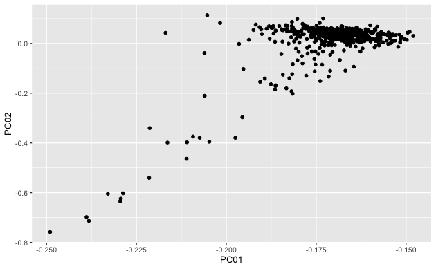

```r
recipe_pca %>% juice() %>%
  ggplot(aes(x = PC01, y = PC02)) +
  geom_point()
```

- we can also use the tidy results of the recipe to do some more analytics

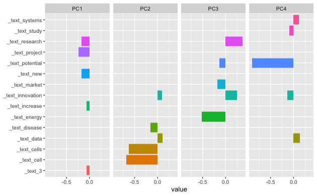

```r
recipe_pca %>%
  tidy(7) %>%
  filter(component %in% paste0("PC", 1:4)) %>%
  group_by(component) %>%
    arrange(desc(value)) %>%
    slice(c(1:2, (n()-2):n())) %>%
  ungroup() %>%
  mutate(component = fct_inorder(component)) %>%
  ggplot(aes(value, terms, fill = terms)) +
  geom_col(show.legend = FALSE) +
  facet_wrap(~component, nrow = 1) +
  labs(y = NULL)
```

- **Note**: Also check further for further dimensionlity reduction steps:
  - tep_kpca():
  - step_ica()
  - step_isomap()
  - step_nmf()

# Topic Models: Latent-Dirichlet-Allocation (LDA)

- While we already did it somewhat ‘on-the-fly’, here a more formal introduction to LDA
- In contrast to dimnesionality reduction techiques mostly aiming at preprocessing data or easing visualization, LDA more aims at EDA and interpretation
- It is a generative approach to identify topics (clusters) within the word-usage in documents.
  - Topics are represented as a probability distribution over the words in the vocabulary. Hhigh probability words can be used to charactrize the topic.
  - Documents are represented as a mixture of topics.

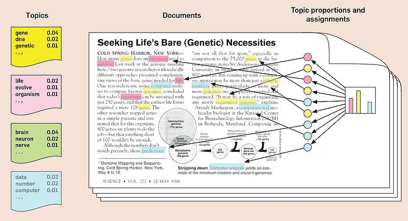

alt text

```r
library(topicmodels)
```

```r
text_dtm
```

[output not shown]

```r
text_lda <- text_dtm %>%
  LDA(k = 6, method = "Gibbs",
      control = list(seed = 1337))
```

- $\beta$ is an output of the LDA model, indicating the propability that a word occurs in a certain topic.
- Therefore, loking at the top probability words of a topic often gives us a good intuition regarding its properties.

```r
# LDA output is defined for tidy(), so we can easily extract it
lda_beta <- text_lda %>%
  tidy(matrix = "beta")
```

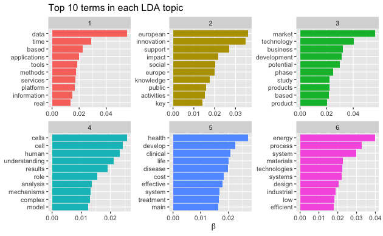

```r
lda_beta %>%
  # slice
  group_by(topic) %>%
  arrange(topic, desc(beta)) %>%
  slice(1:10) %>%
  ungroup() %>%
  # visualize
  mutate(term = reorder_within(term, beta, topic)) %>%
  group_by(topic, term) %>%
  arrange(desc(beta)) %>%
  ungroup() %>%
  ggplot(aes(term, beta, fill = as.factor(topic))) +
  geom_col(show.legend = FALSE) +
  coord_flip() +
  scale_x_reordered() +
  labs(title = "Top 10 terms in each LDA topic",
       x = NULL, y = expression(beta)) +
  facet_wrap(~ topic, ncol = 3, scales = "free")
```

- Documents are represented as a mix of topics. This association of a document to a topic is captured by $\gamma$

[output not shown]

[output cut: 990 more lines]

```r
lda_gamma %>%
  group_by(topic) %>%
  arrange(desc(gamma)) %>%
  slice(1:10) %>%
    ungroup() %>%
  left_join(text %>% select(id, projectacronym) %>% mutate(id = id %>% as.character()), by = c('document' = 'id'))
```

| document | topic | gamma | projectacronym |
| --- | --- | --- | --- |
| 644018 | 1 | 0.5434174 | SUPERSEDE |
| 671500 | 1 | 0.5320814 | SAGE |
| 687289 | 1 | 0.5258900 | Co-ReSyF |
| 685196 | 1 | 0.4259259 | FASTPRK-2 |
| 639595 | 1 | 0.4234801 | Hi-EST |
| 645011 | 1 | 0.4227053 | SERECA |
| 642743 | 1 | 0.4215054 | WiVi-2020 |
| 700478 | 1 | 0.4100295 | RANGER |
| 738483 | 1 | 0.4062016 | IoTEE |
| 662690 | 1 | 0.4057971 | NEW ARYEL |

[output cut: 50 more lines]

```r
library(LDAvis)
```

```r
topicmodels_json_ldavis <- function(fitted, doc_dtm, method = "PCA"){
  require(topicmodels); require(dplyr); require(LDAvis)

  # Find required quantities
  phi <- posterior(text_lda)$terms %>% as.matrix() # Topic-term distribution
  theta <- posterior(fitted)$topics %>% as.matrix() # Document-topic matrix

  text_tidy <- doc_dtm %>% tidy()
  vocab <- colnames(phi)
  doc_length <- tibble(document = rownames(theta)) %>% left_join(text_tidy %>% count(document, wt = count), by = 'document')
  tf <- tibble(term = vocab) %>% left_join(text_tidy %>% count(term, wt = count), by = "term")

  if(method == "PCA"){mds <- jsPCA}
  if(method == "TSNE"){library(tsne); mds <- function(x){tsne(svd(x)$u)} }

  # Convert to json
  json_lda <- LDAvis::createJSON(phi = phi, theta = theta, vocab = vocab, doc.length = doc_length %>% pull(n), term.frequency = tf %>% pull(n),
                                 reorder.topics = FALSE, mds.method = mds,plot.opts = list(xlab = "Dim.1", ylab = "Dim.2"))
  return(json_lda)
}
```

```r
library(LDAvis)
json_lda <- topicmodels_json_ldavis(fitted = text_lda,
                                    doc_dtm = text_dtm,
                                    method = "TSNE")

json_lda %>% serVis(out.dir = 'LDAviz')
```

[interactive chart not shown]

- Note that an LDA can also be performed via a recipe:

```r
recipe_lda <- recipe_base %>% # tokenize
  step_untokenize(text) %>% # Is a bit silly, needs the full text vectors instead of tokens....
  step_lda(text, num_topics = 6) %>% # LDA
  prep()
```

```r
recipe_lda %>% juice()
```

| id | lda_text_w1 | lda_text_w2 | lda_text_w3 | lda_text_w4 | lda_text_w5 | lda_text_w6 |
| --- | --- | --- | --- | --- | --- | --- |
| 683373 | 0.046153846 | 0.115384615 | 0.115384615 | 0.24615385 | 0.353846154 | 0.123076923 |
| 745114 | 0.011538462 | 0.080769231 | 0.173076923 | 0.39230769 | 0.100000000 | 0.242307692 |
| 769638 | 0.200000000 | 0.750000000 | 0.050000000 | 0.00000000 | 0.000000000 | 0.000000000 |
| 651039 | 0.066666667 | 0.191666667 | 0.283333333 | 0.15833333 | 0.075000000 | 0.225000000 |
| 715775 | 0.027272727 | 0.084848485 | 0.100000000 | 0.41818182 | 0.109090909 | 0.260606061 |
| 665403 | 0.185714286 | 0.114285714 | 0.085714286 | 0.17142857 | 0.257142857 | 0.185714286 |
| 652511 | 0.000000000 | 0.000000000 | 0.166666667 | 0.26666667 | 0.133333333 | 0.433333333 |
| 635975 | 0.225000000 | 0.225000000 | 0.300000000 | 0.15000000 | 0.100000000 | 0.000000000 |
| 715767 | 0.073333333 | 0.086666667 | 0.173333333 | 0.40666667 | 0.233333333 | 0.026666667 |
| 733391 | 0.273684211 | 0.242105263 | 0.131578947 | 0.12105263 | 0.084210526 | 0.147368421 |

[output cut: 489 more lines]

# Embeddings (Bonus)

```r
library(textdata)

glove6b <- embedding_glove27b(dimensions = 100)
glove6b
# These mebeddings can now be loaded with step_wordembeddings
```

```r
library(embed)
```

```r
text_UMAP <- text %>%
  recipe(~.) %>%
  update_role(id, new_role = "id") %>%
  step_tokenize(text, token = 'words') %>% # tokenize
  step_tfidf(text, prefix = NULL) %>% # TFIDF weighting
  step_umap(all_predictors(), n_neighbors = 2) %>%
  prep()
```

# Endnotes

### Packages & Ecosystem

- [`textrecipes`](https://textrecipes.tidymodels.org/)
- [`embed`](https://embed.tidymodels.org/)
- [`topicmodels`](https://cran.r-project.org/web/packages/topicmodels/vignettes/topicmodels.pdf)
- [`text2vec`](http://text2vec.org/)
- [`textdata`](http://text2vec.org/)

### References

Articles: * Blei, David M., Andrew Y. Ng, and Michael I. Jordan. “Latent dirichlet allocation.” Journal of machine Learning research 3, no. Jan (2003): 993-1022. * Jeffrey Pennington, Richard Socher, and Christopher D Manning. Glove: Global vectors for word representation. In Conference on Empirical Methods on Natural Language Processing (EMNLP), pages 1532–1543, 2014

### Further sources

- [Julia Silge’s Blog](https://juliasilge.com/): Full of great examples of predictive modeling, NLP, and the combination fo both, using tidy ecosystems
- [Emil Hvitfeldt’s Blog](https://www.hvitfeldt.me/): Likewise, full of great examples of applied tidy ML & NLP in R